# Beta diversity of microbes on diferent frog skins

Roger Calvas

2026-11-16

# Goals

1. Load in phyloseq data.
2. Evaluate sequencing depth and remove samples, if needed.
3. Normalize the read counts between samples.
4. Calculate community **dis**similarities. Numbers between 0 and 1. If 0, completely similar versus if they are 1, then they’re completely dissimilar.
   1. **Sorensen**: Shared Species as a binary value: Abundance-unweighted
   2. **Bray-Curtis**: Shared Abundant species: Abundance-weighted
5. Run statistics with functions from the vegan R package:
   1. PERMANOVA with `adonis2()`.
   2. betadispR with `betadisper()` and `permutest()`.
6. Visualize the community data with two unconstrained Ordinations:
   1. **PCoA**: Linear Method. Eigenvalue = how much variation is explained by each axis. Choose to view axis 1, 2, 3, etc. and plot them together.
   2. **NMDS**: Non-linear. Smush multiple Dimensions into 2 or 3 axes. Need to report Stress value (ideally <0.15).
1. We will need the `clean_physeq.RData`

## Outputs

*This is an exciting analysis!!! We get to answer another one of our scientific questions!*

1. Calculated beta-diversity dissimilarity measures (*e.g.* Sorensen, Bray-Curtis, abundance-unweighted and -weighted UniFrac) across every sample.
2. Ordination figures (*i.e.,* PCoA/NMDS) to include in the scientific paper that visualize the data as it relates to the scientific question.
3. Statistical tests (*i.e.,* PERMANOVA & betadisper) conveying the measured and quantified changes and patterns in biodiversity.

# Scientific Question

Se relaciona la localidad con la diversidad de la piel de las diferentes especies de rana que lo habitan?

- *Null Hypothesis:* La localidad no se relaciona directamente con la diversidad de la piel de las ranas
- *Alternative Hypothesis:* La diversidad cambia con relacion directa a la localidad

INTERPRETATION #1: What is your scientific question and hypotheses? Do they relate to abundance? Presence/absence? Phylogeny?

# Set up

## Timing of this script

```r
# What time did we start running this script?
start_time <- Sys.time()
```

## Set the seed

```r
set.seed(3980)
```

## Load Packages, colors & functions

```r
pacman::p_load(tidyverse, devtools, phyloseq, patchwork, vegan,
               install = FALSE)

# Load Colors
source("code/colors.R")

# Load functions
source("code/functions.R")
```

# Load in the data

```r
# load phyloseq object
load("data/its/03_PreProcessing/clean_physeq.RData")
clean_physeq
```

```
## phyloseq-class experiment-level object
## otu_table()   OTU Table:         [ 3033 taxa and 34 samples ]
## sample_data() Sample Data:       [ 34 samples by 89 sample variables ]
## tax_table()   Taxonomy Table:    [ 3033 taxa by 9 taxonomic ranks ]
```

```r
# Intuition check on seq depth
min(sample_sums(clean_physeq))
```

```
## [1] 14002
```

# Normalizar conteos

## Explore the Raw Read Counts

```r
# calculate read counts per sample
raw_TotalSeqs_df <-
  clean_physeq %>%
  # Calculate the total number of sequences/reads
  sample_sums() %>%
  data.frame()

# Take a look
head(raw_TotalSeqs_df)
```

```
##             .
## ANF-004 52145
## ANF-006 66935
## ANF-007 38988
## ANF-011 51603
## ANF-018 47765
## ANF-021 54641
```

```r
# Rename the column
colnames(raw_TotalSeqs_df)[1] <- "TotalSeqs"

# add a new column of num_ASVs (RAW, non-noramlized # ASVs)
raw_TotalSeqsASVs_df <-
  raw_TotalSeqs_df %>%
  mutate(num_ASVs = colSums(otu_table(clean_physeq) > 1))

#View(raw_TotalSeqsASVs_df)

# Plot histogram of seq depth
rawSeq_histogram <-
  raw_TotalSeqsASVs_df %>%
  ggplot(aes(x = TotalSeqs)) +
  geom_histogram(bins = 50)  +
  labs(title = "Raw Seq Depth Histogram",
       x = "Total sequences",
       y = "Number of samples") +
  theme_bw()

# Plot Seq Depth versus num_ASVs
rawSeq_vs_numASV_plot <-
  raw_TotalSeqsASVs_df %>%
  ggplot(aes(x = num_ASVs, y = TotalSeqs)) +
  geom_point() +
  geom_smooth(method = "lm") +
  labs(title = "Seq Depth vs # ASVs",
       x = "Total ASVs per sample",
       y = "Total seqs per sample") +
  theme_bw()

# is it significant?
summary(lm(TotalSeqs ~ num_ASVs, data = raw_TotalSeqsASVs_df))
```

```
##
## Call:
## lm(formula = TotalSeqs ~ num_ASVs, data = raw_TotalSeqsASVs_df)
##
## Residuals:
##    Min     1Q Median     3Q    Max
## -21468  -7930  -1324   9470  27219
##
## Coefficients:
##             Estimate Std. Error t value Pr(>|t|)
## (Intercept) 28208.57    4026.57   7.006 6.12e-08 ***
## num_ASVs      111.72      31.03   3.600  0.00106 **
## ---
## Signif. codes:  0 '***' 0.001 '**' 0.01 '*' 0.05 '.' 0.1 ' ' 1
##
## Residual standard error: 13010 on 32 degrees of freedom
## Multiple R-squared:  0.2883, Adjusted R-squared:  0.2661
## F-statistic: 12.96 on 1 and 32 DF,  p-value: 0.00106
```

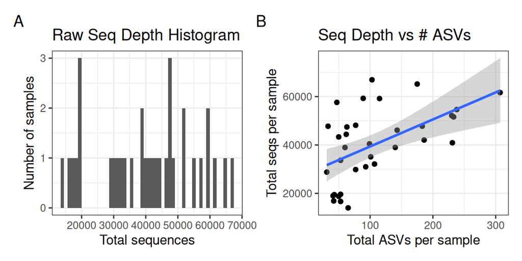

```r
# Put the two plots together.
rawSeq_histogram + rawSeq_vs_numASV_plot +
  plot_annotation(tag_levels = "A")
```

INTERPRETATION #2: Evaluating the above plots, what did you scale the read counts to in your dataset? Why did you choose that number? Do you think it is sufficient to perform a beta-diversity analysis and accurately compare your data to one another?

## Scale Read Counts

```r
min(sample_sums(clean_physeq))
```

```
## [1] 14002
```

```r
# Scale the reads
scaled_physeq <-
  clean_physeq %>%
  scale_reads(round = "matround")

# Look at it
scaled_physeq
```

```
## phyloseq-class experiment-level object
## otu_table()   OTU Table:         [ 3030 taxa and 34 samples ]
## sample_data() Sample Data:       [ 34 samples by 89 sample variables ]
## tax_table()   Taxonomy Table:    [ 3030 taxa by 9 taxonomic ranks ]
```

```r
# Save it
save(scaled_physeq, file ="data/its/05_Ordination/scaled_physeq.RData")

# Look at it more!
#View(data.frame(otu_table(clean_physeq)))
#View(data.frame(otu_table(scaled_physeq)))

# Confirm seq read depth of scaled_physeq
scaled_TotalSeqs_df <-
  scaled_physeq %>%
  sample_sums() %>%
  data.frame()

colnames(scaled_TotalSeqs_df)[1] <- "TotalSeqs"

# add a new column of num_ASVs (RAW, non-noramlized # ASVs)
scaled_TotalSeqsASVs_df <-
  scaled_TotalSeqs_df %>%
  mutate(num_ASVs = colSums(otu_table(scaled_physeq) > 1))

# Plot it!
scaledSeq_histogram <-
  scaled_TotalSeqs_df %>%
  ggplot(aes(x = TotalSeqs)) +
  geom_histogram(bins = 50) +
  labs(title = "Scaled Seq Depth Histogram")+
  theme_bw()

# Scaling always gives us a range!
range(scaled_TotalSeqs_df$TotalSeqs)
```

```
## [1] 13998 14014
```

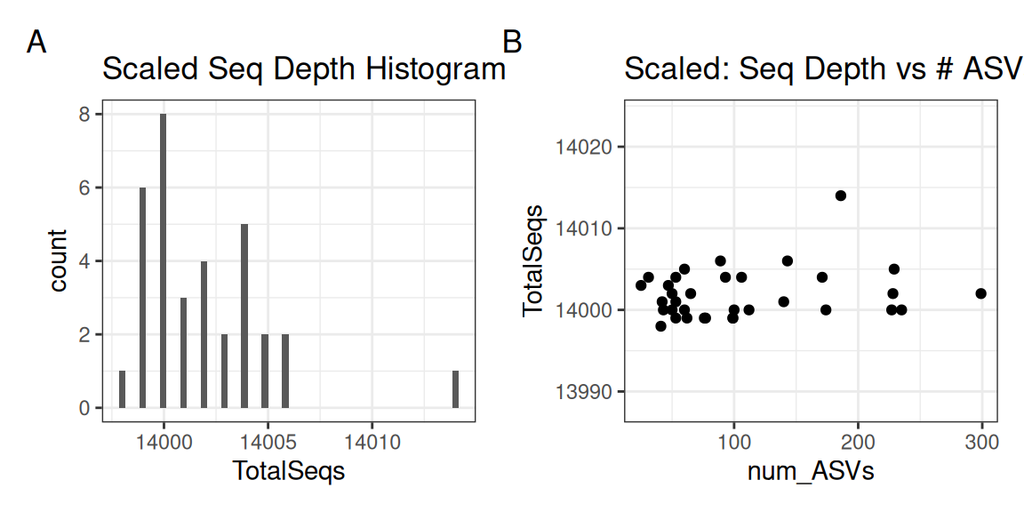

```r
# Set the axis min and max for the next plot
max_y <- max(scaled_TotalSeqs_df$TotalSeqs) + 10
min_y <- min(scaled_TotalSeqs_df$TotalSeqs) - 10

# Now, draw the plot
scaledSeq_vs_numASV_plot <-
  scaled_TotalSeqsASVs_df %>%
  ggplot(aes(x = num_ASVs, y = TotalSeqs)) +
  geom_point() +
  scale_y_continuous(limits = c(min_y, max_y)) +
  #geom_smooth(method = "lm") +
  theme_bw() +
  labs(title = "Scaled: Seq Depth vs # ASVs")

# Put the two plots together.
scaledSeq_histogram + scaledSeq_vs_numASV_plot +
  plot_annotation(tag_levels = "A")
```

## Create metadata after pruning

```r
# Create Metadata_df after the prune
metadata_df <-
  scaled_physeq %>%
  sample_data() %>%
  data.frame()
```

INTERPRETATION #3: Evaluate the scaled read count plots above. Are the total number of sequences across all of your samples in the same general range? What is the minimum and maximum (i.e., the range) of the sequencing depth? How was the relationship with the number of ASVs modified after scaling the read counts?

# B-diversity

## Calculate Dissimilarity

```r
#Jaccard Dissimilarity
scaled_jaccard_dist <- phyloseq::distance(scaled_physeq, method = "jaccard", binary = TRUE)

# What does it look like?
class(scaled_jaccard_dist)
```

```
## [1] "dist"
```

```r
str(scaled_jaccard_dist)
```

```
##  'dist' num [1:561] 0.953 0.975 0.973 0.978 0.985 ...
##  - attr(*, "maxdist")= num 1
##  - attr(*, "Size")= int 34
##  - attr(*, "Labels")= chr [1:34] "ANF-004" "ANF-006" "ANF-007" "ANF-011" ...
##  - attr(*, "Diag")= logi FALSE
##  - attr(*, "Upper")= logi FALSE
##  - attr(*, "method")= chr "binary jaccard"
##  - attr(*, "call")= language vegdist(x = c(0, 0, 0, 0, 0, 0, 0, 0, 0, 0, 0, 0, 0, 0, 12806, 121, 0,  0, 0, 0, 0, 0, 0, 0, 0, 0, 79, 0, 0, 0, 0| __truncated__ ...
```

```r
#head(as.matrix(scaled_jaccard_dist))

scaled_sorensen_dist <- phyloseq::distance(scaled_physeq, method = "bray", binary = TRUE)

# Bray-Curtis Dissimiliarty
scaled_Bray_dist <- phyloseq::distance(scaled_physeq, method = "bray", binary = FALSE)
```

INTERPRETATION #4: Which dissimilarity metric is most related to your scientific question?

## Permanovas for bray curtis

```r
# bray
## 1. Run with by = terms for R² values, sensitive to order of variables!
##
bray_status_adonis_terms1 <- adonis2(scaled_Bray_dist ~ localidad + posicion_vertical_cm, data = metadata_df, by = "terms")
bray_status_adonis_terms1
```

```
## Permutation test for adonis under reduced model
## Terms added sequentially (first to last)
## Permutation: free
## Number of permutations: 999
##
## adonis2(formula = scaled_Bray_dist ~ localidad + posicion_vertical_cm, data = metadata_df, by = "terms")
##                      Df SumOfSqs      R2      F Pr(>F)
## localidad             4   2.1871 0.13867 1.1680  0.001 ***
## posicion_vertical_cm  1   0.4774 0.03027 1.0198  0.350
## Residual             28  13.1076 0.83106
## Total                33  15.7721 1.00000
## ---
## Signif. codes:  0 '***' 0.001 '**' 0.01 '*' 0.05 '.' 0.1 ' ' 1
```

```r
# Check the order of the terms
bray_status_adonis_terms2 <- adonis2(scaled_Bray_dist ~ posicion_vertical_cm + localidad, data = metadata_df, by = "terms")
bray_status_adonis_terms2
```

```
## Permutation test for adonis under reduced model
## Terms added sequentially (first to last)
## Permutation: free
## Number of permutations: 999
##
## adonis2(formula = scaled_Bray_dist ~ posicion_vertical_cm + localidad, data = metadata_df, by = "terms")
##                      Df SumOfSqs      R2      F Pr(>F)
## posicion_vertical_cm  1   0.4627 0.02934 0.9885  0.583
## localidad             4   2.2018 0.13960 1.1758  0.002 **
## Residual             28  13.1076 0.83106
## Total                33  15.7721 1.00000
## ---
## Signif. codes:  0 '***' 0.001 '**' 0.01 '*' 0.05 '.' 0.1 ' ' 1
```

```r
## 2. Compara si hay interaccion entre localidad y altura juntas (by margin)
bray_status_adonis_margin <- adonis2(scaled_Bray_dist ~ localidad * posicion_vertical_cm, data = metadata_df, by = "margin")
bray_status_adonis_margin
```

```
## Permutation test for adonis under reduced model
## Marginal effects of terms
## Permutation: free
## Number of permutations: 999
##
## adonis2(formula = scaled_Bray_dist ~ localidad * posicion_vertical_cm, data = metadata_df, by = "margin")
##                                Df SumOfSqs      R2     F Pr(>F)
## localidad:posicion_vertical_cm  4   1.9695 0.12487 1.061  0.033 *
## Residual                       24  11.1380 0.70619
## Total                          33  15.7721 1.00000
## ---
## Signif. codes:  0 '***' 0.001 '**' 0.01 '*' 0.05 '.' 0.1 ' ' 1
```

## Permanovas for Sorensen

```r
# sorensen
## 1. Run with by = terms for R² values, sensitive to order of variables!
## ALWAYS check and confirm the order of your terms and how they interact with each other.
sorensen_status_adonis_terms1 <- adonis2(scaled_sorensen_dist ~ localidad + posicion_vertical_cm, data = metadata_df, by = "terms")
sorensen_status_adonis_terms1
```

```
## Permutation test for adonis under reduced model
## Terms added sequentially (first to last)
## Permutation: free
## Number of permutations: 999
##
## adonis2(formula = scaled_sorensen_dist ~ localidad + posicion_vertical_cm, data = metadata_df, by = "terms")
##                      Df SumOfSqs      R2      F Pr(>F)
## localidad             4   2.1317 0.13802 1.1638  0.001 ***
## posicion_vertical_cm  1   0.4909 0.03178 1.0720  0.081 .
## Residual             28  12.8220 0.83020
## Total                33  15.4446 1.00000
## ---
## Signif. codes:  0 '***' 0.001 '**' 0.01 '*' 0.05 '.' 0.1 ' ' 1
```

```r
# Check the order of the terms
sorensen_status_adonis_terms2 <- adonis2(scaled_sorensen_dist ~ posicion_vertical_cm + localidad, data = metadata_df, by = "terms")
sorensen_status_adonis_terms2
```

```
## Permutation test for adonis under reduced model
## Terms added sequentially (first to last)
## Permutation: free
## Number of permutations: 999
##
## adonis2(formula = scaled_sorensen_dist ~ posicion_vertical_cm + localidad, data = metadata_df, by = "terms")
##                      Df SumOfSqs      R2      F Pr(>F)
## posicion_vertical_cm  1   0.4852 0.03141 1.0595  0.118
## localidad             4   2.1374 0.13839 1.1669  0.001 ***
## Residual             28  12.8220 0.83020
## Total                33  15.4446 1.00000
## ---
## Signif. codes:  0 '***' 0.001 '**' 0.01 '*' 0.05 '.' 0.1 ' ' 1
```

```r
## 2. Run with by = "margin" for marginal p-values, which we can compare to the residuals from the first one.
sorensen_status_adonis_margin <- adonis2(scaled_sorensen_dist ~ localidad * posicion_vertical_cm, data = metadata_df, by = "margin")
sorensen_status_adonis_margin
```

```
## Permutation test for adonis under reduced model
## Marginal effects of terms
## Permutation: free
## Number of permutations: 999
##
## adonis2(formula = scaled_sorensen_dist ~ localidad * posicion_vertical_cm, data = metadata_df, by = "margin")
##                                Df SumOfSqs      R2      F Pr(>F)
## localidad:posicion_vertical_cm  4   1.8979 0.12289 1.0424  0.057 .
## Residual                       24  10.9241 0.70731
## Total                          33  15.4446 1.00000
## ---
## Signif. codes:  0 '***' 0.001 '**' 0.01 '*' 0.05 '.' 0.1 ' ' 1
```

INTERPRETATION #5: Using the above example to guide you, run the appropriate PERMANOVA for your scientific question and interpret the results. What biological conclusion can you draw from your PERMANOVA results?

# Betadisper: Testing Variances/Dispersions

## Sorensen

```r
# Homogeneity of Disperson test with beta dispr
# Sorensen Betadisper - status
dispr_sorensen_localidad <- betadisper(scaled_sorensen_dist, metadata_df$localidad)
# permutest() performs a non-parametric permutation test, which is robust and valid for the kind of data used in beta diversity analysis (e.g., dissimilarity matrices).
permutest(dispr_sorensen_localidad)
```

```
##
## Permutation test for homogeneity of multivariate dispersions
## Permutation: free
## Number of permutations: 999
##
## Response: Distances
##           Df    Sum Sq    Mean Sq      F N.Perm Pr(>F)
## Groups     4 0.0005451 0.00013627 0.3911    999  0.809
## Residuals 29 0.0101039 0.00034841
```

```r
# Homogeneidad de dispersión para Bray-Curtis por localidad
  dispr_bray_localidad <- betadisper(scaled_Bray_dist, metadata_df$localidad)
permutest(dispr_bray_localidad)
```

```
##
## Permutation test for homogeneity of multivariate dispersions
## Permutation: free
## Number of permutations: 999
##
## Response: Distances
##           Df    Sum Sq    Mean Sq      F N.Perm Pr(>F)
## Groups     4 0.0013109 0.00032772 0.7532    999  0.563
## Residuals 29 0.0126187 0.00043513
```

INTERPRETATION #6: Using the above example to guide you, run the appropriate betadisper() and permutest() for your scientific question and interpret the results. What biological conclusion can you draw from your dispersion analysis?

INTERPRETATION #7: Taking into account both the betadisper()/permutest() and the PERMANOVA (adonis2()) test that you ran, what biological conclusion can you draw regarding your data?

# PCoA: Principal Coordinate analysis

```r
### SORENSEN
# First, calculate PCoA with Soresen
scaled_soren_pcoa <-
  ordinate(physeq = scaled_physeq,
         method = "PCoA",
         distance = "bray", binary = TRUE)

# Take a quick look
str(scaled_soren_pcoa)
```

```
## List of 5
##  $ correction: chr [1:2] "none" "1"
##  $ note      : chr "There were no negative eigenvalues. No correction was applied"
##  $ values    :'data.frame':  33 obs. of  5 variables:
##   ..$ Eigenvalues   : num [1:33] 0.719 0.67 0.637 0.607 0.582 ...
##   ..$ Relative_eig  : num [1:33] 0.0465 0.0434 0.0412 0.0393 0.0377 ...
##   ..$ Broken_stick  : num [1:33] 0.1239 0.0936 0.0784 0.0683 0.0608 ...
##   ..$ Cumul_eig     : num [1:33] 0.0465 0.0899 0.1312 0.1705 0.2082 ...
##   ..$ Cumul_br_stick: num [1:33] 0.124 0.218 0.296 0.364 0.425 ...
##  $ vectors   : num [1:34, 1:33] -0.1967 -0.0718 -0.1595 -0.2833 -0.1661 ...
##   ..- attr(*, "dimnames")=List of 2
##   .. ..$ : chr [1:34] "ANF-004" "ANF-006" "ANF-007" "ANF-011" ...
##   .. ..$ : chr [1:33] "Axis.1" "Axis.2" "Axis.3" "Axis.4" ...
##  $ trace     : num 15.4
##  - attr(*, "class")= chr "pcoa"
```

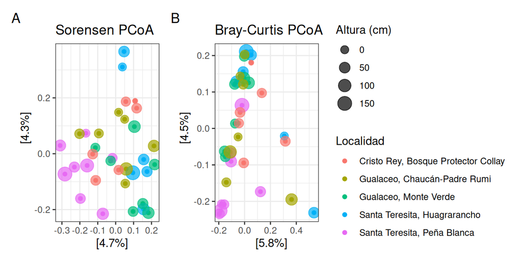

```r
# Plot it
sorensen_pcoa_plot <-
      plot_ordination(physeq = scaled_physeq,
                      ordination = scaled_soren_pcoa,
                      color = "localidad",
                      title = "Sorensen PCoA") +
      geom_point(aes(size = posicion_vertical_cm, color = localidad), alpha = 0.7) +
      scale_color_manual(values = localidad_colors, name = "Localidad") +
      scale_size_continuous(name = "Altura (cm)", range = c(2, 6)) +
      theme_bw() +
      theme(legend.position = "right")
### BRAY-CURTIS PCoA
scaled_bray_pcoa <-
  ordinate(physeq = scaled_physeq,
           method = "PCoA",
           distance = "bray", binary = FALSE)
# Plot it
bray_pcoa_plot <-
  plot_ordination(physeq = scaled_physeq,
                  ordination = scaled_bray_pcoa,
                  color = "localidad",
                  title = "Bray-Curtis PCoA") +
  geom_point(aes(size = posicion_vertical_cm, color = localidad), alpha = 0.7) +
  scale_color_manual(values = localidad_colors, name = "Localidad") +
  scale_size_continuous(name = "Altura (cm)", range = c(2, 6)) +
  theme_bw() +
  theme(legend.position = "right")

# Mostrar ambos PCoA juntos
sorensen_pcoa_plot + bray_pcoa_plot +
  plot_layout(guides = "collect") +
  plot_annotation(tag_levels = "A")
```

```r
# Podemos calcular proyecciones con envfit para hacer un biplot y explorar cargas inferidas
soren_envfit <- envfit(scaled_soren_pcoa$vectors[, 1:2],
                       metadata_df %>% dplyr::select(posicion_vertical_cm),
                       permutations = 999, na.rm = TRUE)
print(soren_envfit)
```

```
##
## ***VECTORS
##
##                        Axis.1   Axis.2     r2 Pr(>r)
## posicion_vertical_cm -0.12276 -0.99244 0.1346   0.11
## Permutation: free
## Number of permutations: 999
```

INTERPRETATION #8: Plot your data using a PCoA. Interpret what you can conclude from the PCoA.

## 6b. NMDS: Non-Metric Multidimensional Scaling

```r
## SORENSEN NMDS
scaled_soren_nmds <-
  ordinate(physeq = scaled_physeq,
           method = "NMDS",
           distance = "bray", binary = TRUE)
```

```
## Square root transformation
## Wisconsin double standardization
## *** Best solution was not repeated -- monoMDS stopping criteria:
##     20: stress ratio > sratmax
```

```r
# Plot Sorensen NMDS
sorensen_nmds_plot <-
  plot_ordination(physeq = scaled_physeq,
                  ordination = scaled_soren_nmds,
                  color = "localidad",
                  title = "Sorensen NMDS") +
  geom_point(aes(size = posicion_vertical_cm, color = localidad), alpha = 0.7) +
  scale_color_manual(values = localidad_colors, name = "Localidad") +
  scale_size_continuous(name = "Altura (cm)", range = c(2, 6)) +
  theme_bw() +
  theme(legend.position = "right")

### BRAY-CURTIS NMDS
scaled_bray_nmds <-
  ordinate(physeq = scaled_physeq,
           method = "NMDS",
           distance = "bray", binary = FALSE)
```

```
## Square root transformation
## Wisconsin double standardization
## *** Best solution repeated 1 times
```

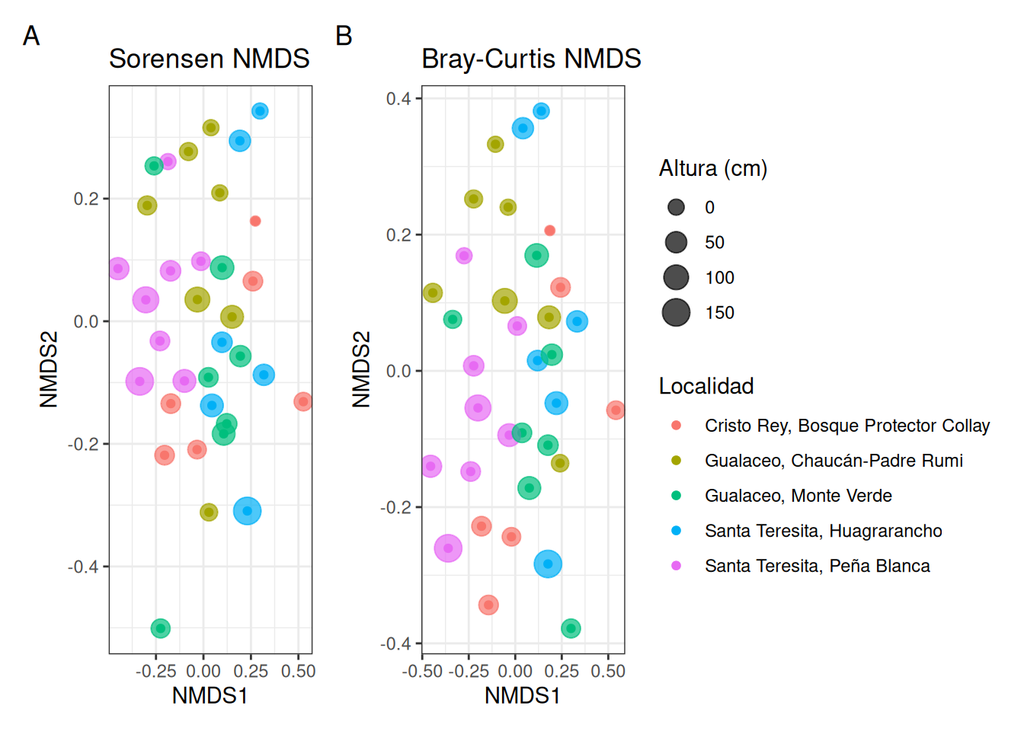

```r
# Plot Bray-Curtis NMDS
bray_nmds_plot <-
  plot_ordination(physeq = scaled_physeq,
                  ordination = scaled_bray_nmds,
                  color = "localidad",
                  title = "Bray-Curtis NMDS") +
  geom_point(aes(size = posicion_vertical_cm, color = localidad), alpha = 0.7) +
  scale_color_manual(values = localidad_colors, name = "Localidad") +
  scale_size_continuous(name = "Altura (cm)", range = c(2, 6)) +
  theme_bw() +
  theme(legend.position = "right")

# Mostrar ambos NMDS juntos
sorensen_nmds_plot + bray_nmds_plot +
  plot_layout(guides = "collect") +
  plot_annotation(tag_levels = "A")
```

INTERPRETATION #9: Plot your data using NMDS. Interpret what you can conclude from the NMDS.

## All ordinations together!

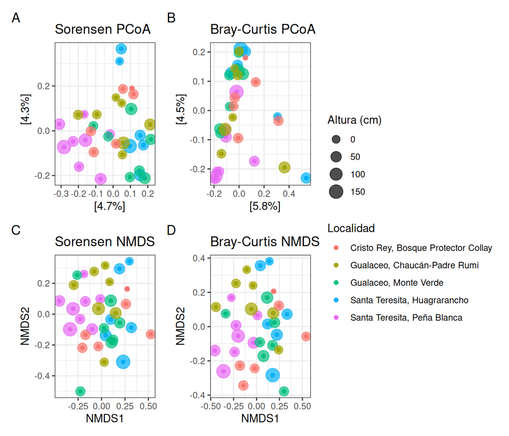

```r
sorensen_pcoa_plot + bray_pcoa_plot +
sorensen_nmds_plot + bray_nmds_plot +
  plot_layout(guides = "collect") +
  plot_annotation(tag_levels = "A")
```

INTERPRETATION #10: Plot both the PCoA and NMDS together. Which of the two visualizations work best for your data? Explain your reasoning.

# Final info for Reproducibility

## Check Render Time

```r
# Take the time now that we are at the end of the script
end_time <- Sys.time()
end_time
```

```
## [1] "2026-11-16 02:21:15 UTC"
```

```r
# Echo the elapsed time
elapsed_time <- round((end_time - start_time), 3)
elapsed_time
```

```
## Time difference of 5.327 secs
```